# Project: Investigate a Dataset - [Dataset-name]

### Research Question 1 (What percentage of patients suffer from chronic diseases?!)

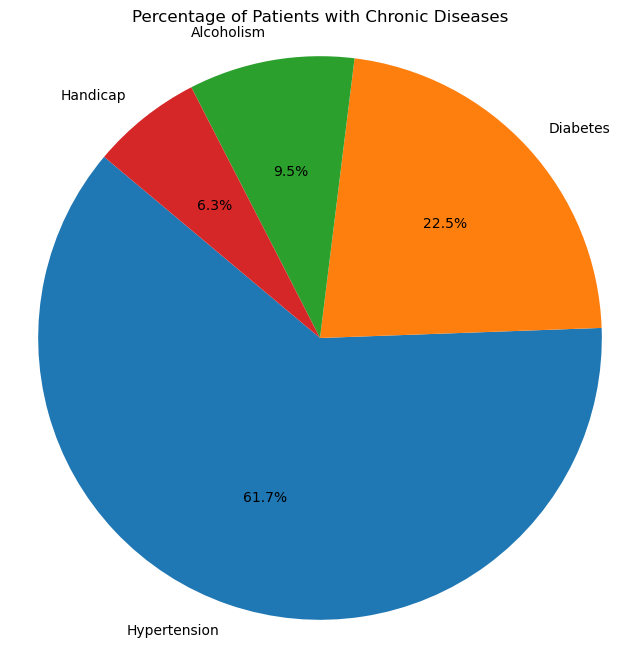

```python
def plot_chronic_diseases(df):
    """
    Calculate and plot the percentage of patients with chronic diseases.

    Args:
        df (pd.DataFrame): The dataframe containing the data.
    """
    # Calculate percentages
    chronic_diseases = {
        'Hypertension': (df['Hypertension'].sum() / len(df)) * 100,
        'Diabetes': (df['Diabetes'].sum() / len(df)) * 100,
        'Alcoholism': (df['Alcoholism'].sum() / len(df)) * 100,
        'Handicap': (df['Handicap'].sum() / len(df)) * 100,
    }

    # Plot pie chart
    plt.figure(figsize=(8, 8))
    plt.pie(
        chronic_diseases.values(),
        labels=chronic_diseases.keys(),
        autopct='%1.1f%%',
        startangle=140
    )
    plt.title('Percentage of Patients with Chronic Diseases')
    plt.axis('equal')
    plt.show()

# Call the function
plot_chronic_diseases(df)
```

```python
# counts the values in the 'Hypertension' column and returns the number of occurrences of each value
df['Hypertension'].value_counts()
```

```
Hypertension
False    88726
True     21801
Name: count, dtype: int64
```

```python
# counts the values in the 'Handcap' column and returns the number of occurrences of each value
df['Handicap'].value_counts()
```

```
Handicap
False    108286
True       2241
Name: count, dtype: int64
```

```python
# counts the values in the 'Alcoholism' column and returns the number of occurrences of each value
df['Alcoholism'].value_counts()
```

```
Alcoholism
False    107167
True       3360
Name: count, dtype: int64
```

```python
# counts the values in the 'Diabetes' column and returns the number of occurrences of each value
df['Diabetes'].value_counts()
```

```
Diabetes
False    102584
True       7943
Name: count, dtype: int64
```

### Research Question 2 (What is the attendance and absence rate?)

```python
# Analyze the attendance and no-show rates
attendance_rate = df['NoShow'].value_counts(normalize=True) * 100

attendance_rate
```

```
NoShow
No     79.806744
Yes    20.193256
Name: proportion, dtype: float64
```

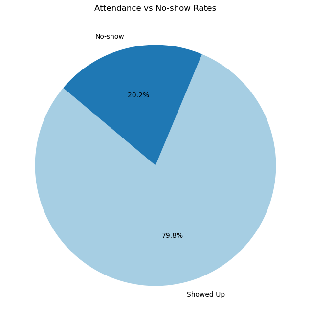

```python
# Calculate the attendance and no-show rates
attendance_rate = df['NoShow'].value_counts(normalize=True) * 100

# Plot a pie chart showing attendance vs no-show rates
plt.figure(figsize=(8, 8))
plt.pie(
    attendance_rate,
    labels=['Showed Up', 'No-show'],
    autopct='%1.1f%%',
    startangle=140,
    colors=plt.cm.Paired.colors
)
plt.title('Attendance vs No-show Rates')
plt.show()
```

The pie chart above illustrates the proportion of patients who showed up for their appointments versus those who did not (no-shows). This visualization provides a clear understanding of attendance behavior in the dataset, which is essential for identifying trends or patterns that may affect the efficiency of scheduling and resource allocation in healthcare facilities.

### Research Question 3 (What is the effect of gender, receiving messages and pressure on attendance?)

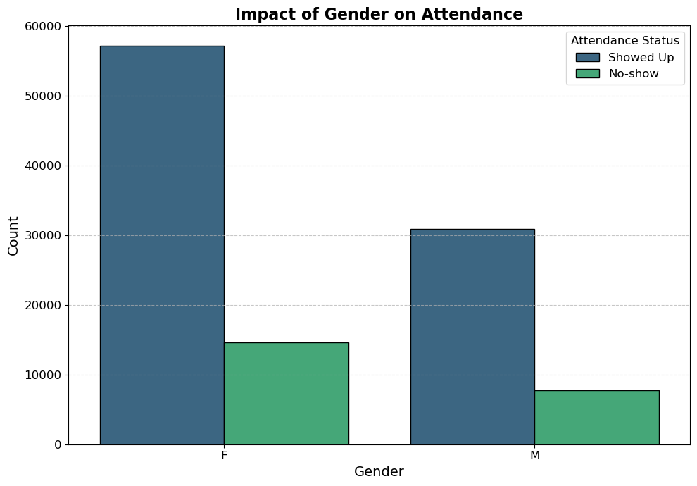

```python
# Plot 1: Gender vs No-show with enhancements
plt.figure(figsize=(10, 7))

# Create a count plot with enhanced visuals
sns.countplot(
    data=df,
    x='Gender',
    hue='NoShow',
    palette='viridis',
    edgecolor='black'  # Adding edges for clarity
)

# Add a title and axis labels
plt.title('Impact of Gender on Attendance', fontsize=16, fontweight='bold')
plt.xlabel('Gender', fontsize=14)
plt.ylabel('Count', fontsize=14)

# Customize the legend
plt.legend(
    title='Attendance Status',
    labels=['Showed Up', 'No-show'],
    fontsize=12,
    title_fontsize=12,
    loc='upper right'
)

# Add grid lines for better readability
plt.grid(axis='y', linestyle='--', alpha=0.7)

# Customize the tick labels
plt.xticks(fontsize=12)
plt.yticks(fontsize=12)

# Display the plot
plt.tight_layout()  # Adjust layout for better spacing
plt.show()
```

Analyzing the relationship between gender and attendance and absence rates helps determine whether there is an effect of gender on adherence to appointments.

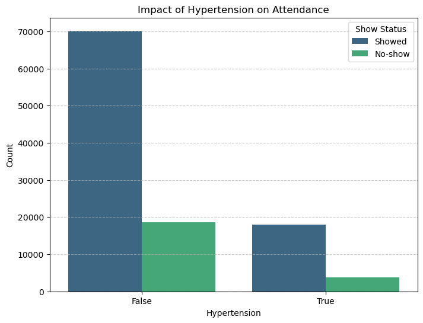

```python
# Plot 2: Hypertension vs No-show
plt.figure(figsize=(8, 6))
sns.countplot(data=df, x='Hypertension', hue='NoShow', palette='viridis')
plt.title('Impact of Hypertension on Attendance')
plt.xlabel('Hypertension')
plt.ylabel('Count')
plt.legend(title='Show Status', labels=['Showed', 'No-show'])
plt.grid(axis='y', linestyle='--', alpha=0.7)
plt.show()
```

Understanding the relationship between patients with hypertension and their behavior toward appointments is important for improving their healthcare.

Interpretation:

Patients with hypertension have lower rates of absenteeism compared to patients without hypertension, which may indicate that they recognize the importance of health appointments. Insights:

Focus on awareness of the importance of attendance for patients without chronic diseases. Improve appointment reminders for patients with hypertension to ensure continued adherence.

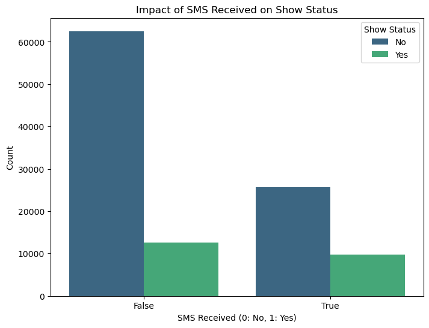

```python
# Plot 3:SMS_received  vs No-show
plt.figure(figsize=(8, 6))
sns.countplot(data=df, x='SMS_received', hue='NoShow', palette='viridis')
plt.title('Impact of SMS Received on Show Status')
plt.xlabel('SMS Received (0: No, 1: Yes)')
plt.ylabel('Count')
plt.legend(title='Show Status')
plt.show()
```

Evaluating the effectiveness of text messages as a tool to remind patients of appointments.

Interpretation:

```python
df['NoShow'] = df['NoShow'].apply(lambda x: 0 if x == "No" else 1)
result = df.groupby('Scholarship')['NoShow'].mean()
print(result)
```

```
Scholarship
False    0.198072
True     0.237363
Name: NoShow, dtype: float64
```

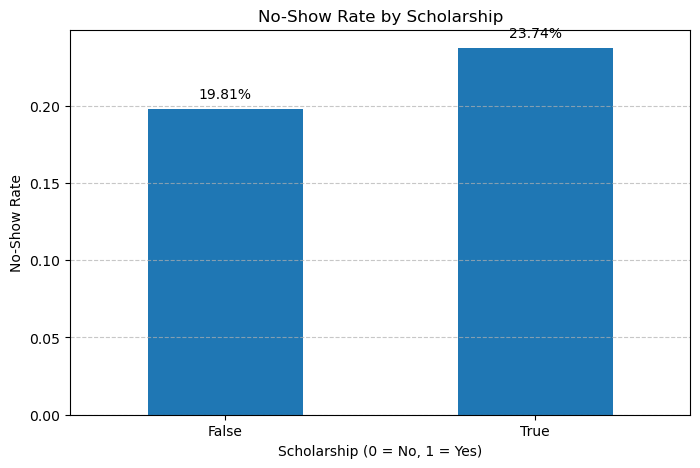

```python
# Draw a graph of the absence rate according to the presence of the scholarship
result.plot(kind='bar', figsize=(8, 5), title='No-Show Rate by Scholarship', ylabel='No-Show Rate', xlabel='Scholarship (0 = No, 1 = Yes)', legend=False)

# Add values to columns
for i, value in enumerate(result):
    plt.text(i, value + 0.005, f"{value:.2%}", ha='center', va='bottom', fontsize=10)

# display drawing
plt.xticks(rotation=0)
plt.grid(axis='y', linestyle='--', alpha=0.7)
plt.show()
```

```python
df['Age_Cust'] = pd.cut(df['Age'], bins=[0, 13, 40, 90], labels=['Childs', 'Adults', 'Seniors'])
age_group_result = df.groupby('Age_Cust')['NoShow'].mean()
print(age_group_result)
```

```
Age_Cust
Childs     0.213495
Adults     0.236405
Seniors    0.172302
Name: NoShow, dtype: float64
```

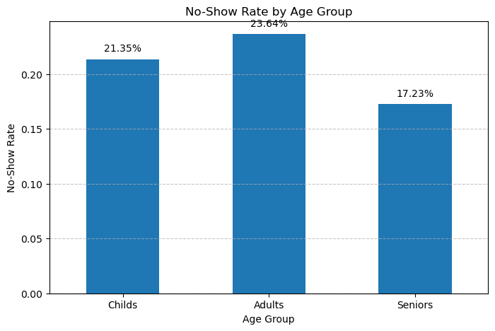

```python
age_group_result.plot(kind='bar', figsize=(8, 5), title='No-Show Rate by Age Group', ylabel='No-Show Rate', xlabel='Age Group', legend=False)

for i, value in enumerate(age_group_result):
    plt.text(i, value + 0.005, f"{value:.2%}", ha='center', va='bottom', fontsize=10)
plt.xticks(rotation=0)
plt.grid(axis='y', linestyle='--', alpha=0.7)
plt.show()
```

Analyzing absences by age group helps understand the impact of age on punctuality.

Interpretation:

```python
df
```

|  | PatientId | AppointmentID | Gender | ScheduledDay | AppointmentDay | Age | Neighbourhood | Scholarship | Hypertension | Diabetes | Alcoholism | Handicap | SMS_received | NoShow | Age_Cust |
| --- | --- | --- | --- | --- | --- | --- | --- | --- | --- | --- | --- | --- | --- | --- | --- |
| 0 | 2.987250e+13 | 5642903 | F | 2016-04-29 18:38:08+00:00 | 2016-04-29 00:00:00+00:00 | 62 | JARDIM DA PENHA | False | True | False | False | False | False | 0 | Seniors |
| 1 | 5.589978e+14 | 5642503 | M | 2016-04-29 16:08:27+00:00 | 2016-04-29 00:00:00+00:00 | 56 | JARDIM DA PENHA | False | False | False | False | False | False | 0 | Seniors |
| 2 | 4.262962e+12 | 5642549 | F | 2016-04-29 16:19:04+00:00 | 2016-04-29 00:00:00+00:00 | 62 | MATA DA PRAIA | False | False | False | False | False | False | 0 | Seniors |
| 3 | 8.679512e+11 | 5642828 | F | 2016-04-29 17:29:31+00:00 | 2016-04-29 00:00:00+00:00 | 8 | PONTAL DE CAMBURI | False | False | False | False | False | False | 0 | Childs |
| 4 | 8.841186e+12 | 5642494 | F | 2016-04-29 16:07:23+00:00 | 2016-04-29 00:00:00+00:00 | 56 | JARDIM DA PENHA | False | True | True | False | False | False | 0 | Seniors |
| ... | ... | ... | ... | ... | ... | ... | ... | ... | ... | ... | ... | ... | ... | ... | ... |
| 110522 | 2.572134e+12 | 5651768 | F | 2016-05-03 09:15:35+00:00 | 2016-06-07 00:00:00+00:00 | 56 | MARIA ORTIZ | False | False | False | False | False | True | 0 | Seniors |
| 110523 | 3.596266e+12 | 5650093 | F | 2016-05-03 07:27:33+00:00 | 2016-06-07 00:00:00+00:00 | 51 | MARIA ORTIZ | False | False | False | False | False | True | 0 | Seniors |
| 110524 | 1.557663e+13 | 5630692 | F | 2016-04-27 16:03:52+00:00 | 2016-06-07 00:00:00+00:00 | 21 | MARIA ORTIZ | False | False | False | False | False | True | 0 | Adults |
| 110525 | 9.213493e+13 | 5630323 | F | 2016-04-27 15:09:23+00:00 | 2016-06-07 00:00:00+00:00 | 38 | MARIA ORTIZ | False | False | False | False | False | True | 0 | Adults |
| 110526 | 3.775115e+14 | 5629448 | F | 2016-04-27 13:30:56+00:00 | 2016-06-07 00:00:00+00:00 | 54 | MARIA ORTIZ | False | False | False | False | False | True | 0 | Seniors |

110527 rows × 15 columns

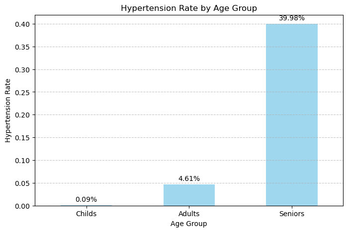

```python
age_group_result = df.groupby('Age_Cust')['Hypertension'].mean()

# Plot the result
plt.figure(figsize=(8, 5))
age_group_result.plot(kind='bar', title='Hypertension Rate by Age Group', ylabel='Hypertension Rate', xlabel='Age Group', legend=False, color='skyblue', alpha=0.8)

# Add percentage labels on each bar
for i, value in enumerate(age_group_result):
    plt.text(i, value + 0.005, f"{value:.2%}", ha='center', va='bottom', fontsize=10)

plt.xticks(rotation=0)
plt.grid(axis='y', linestyle='--', alpha=0.7)
plt.show()
```

### Research Question 4

**( What are the ten most active neighborhoods in terms of the number of medical appointment**?)

```python
# Recalculate the total number of appointments for each neighborhood
appointments_by_neighborhood = df['Neighbourhood'].value_counts()

# Extract the top 10 most active neighborhoods
most_active_neighborhoods = appointments_by_neighborhood.head(10)

# Create a DataFrame for display
most_active_neighborhoods_df = most_active_neighborhoods.reset_index().rename(
    columns={'index': 'Neighborhood', 'Neighbourhood': 'Number of Appointments'}
)

# Display the DataFrame
most_active_neighborhoods_df
```

[output not shown]

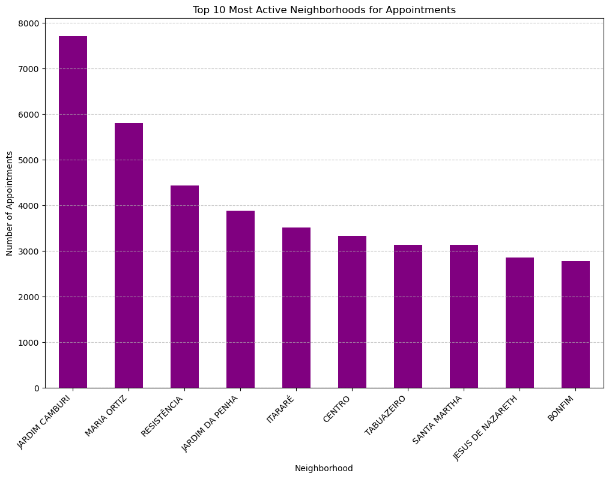

```python
# Plot a bar chart for the top 10 most active neighborhoods
plt.figure(figsize=(12, 8))
most_active_neighborhoods.plot(kind='bar', color='purple')
plt.title('Top 10 Most Active Neighborhoods for Appointments')
plt.xlabel('Neighborhood')
plt.ylabel('Number of Appointments')
plt.xticks(rotation=45, ha='right')
plt.grid(axis='y', linestyle='--', alpha=0.7)
plt.show()
```

Analysis of the most active neighborhoods in appointments

- The graph shows the ten most active neighborhoods in terms of the number of medical appointments.
- The neighborhoods that top the graph may have a high population density or are close to medical centers.

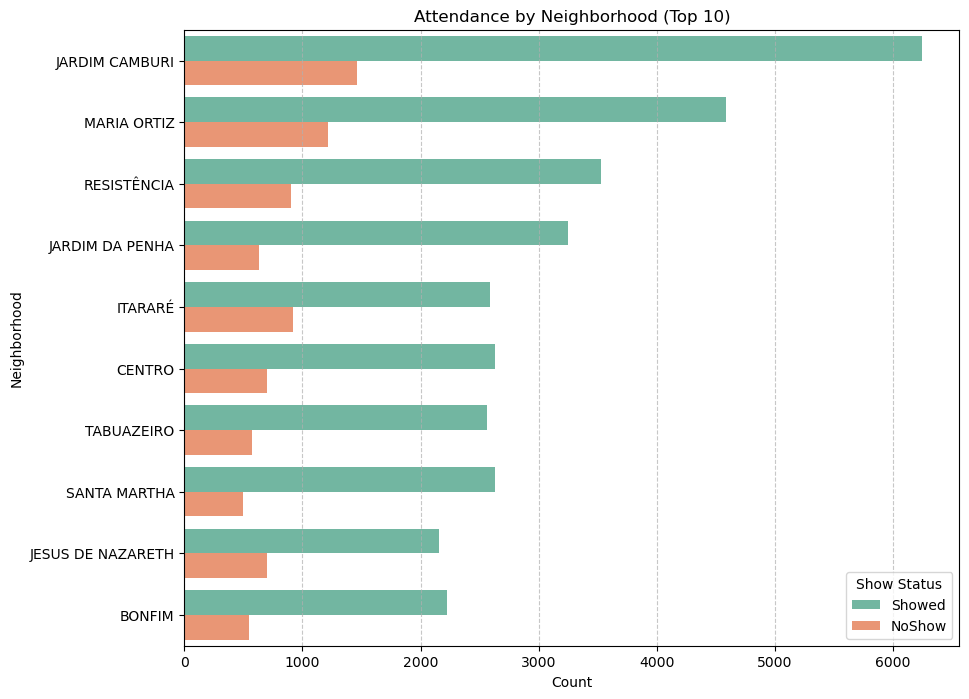

```python
# Filter the top 10 most active neighborhoods based on their counts
top_10_neighborhoods = df['Neighbourhood'].value_counts().head(10).index
filtered_df = df[df['Neighbourhood'].isin(top_10_neighborhoods)]

# Create the plot for Neighborhood vs No-show (Top 10 neighborhoods)
plt.figure(figsize=(10, 8))
sns.countplot(data=filtered_df, y='Neighbourhood', hue='NoShow', palette='Set2', order=top_10_neighborhoods)
plt.title('Attendance by Neighborhood (Top 10)')
plt.xlabel('Count')
plt.ylabel('Neighborhood')
plt.legend(title='Show Status', labels=['Showed', 'NoShow'])
plt.grid(axis='x', linestyle='--', alpha=0.7)
plt.show()
```

Some neighborhoods have relatively high absenteeism rates compared to others.

## Conclusions

### Question:

**What percentage of patients suffer from chronic diseases?**

#### Percentage of Patients with Chronic Diseases:

**Results**:

### Question:

**What is the attendance and absence rate?**

The pie chart illustrates the attendance and no-show rates for medical appointments:

- **Attendance (Showed Up):** The majority of patients attended their appointments.
- **No-show:** A minority of patients missed their appointments.

**Results**:

- This analysis highlights the attendance patterns, which can be further analyzed to improve patient retention and reduce no-shows.

### Question:

**What is the effect of gender, receiving messages, and hypertension on attendance?**

#### 1. **Impact of Gender on Attendance (Gender vs No-show):**

- Females have a higher number of appointments than males, regardless of attendance or no-show status.
- No-show rates are similar across genders, indicating that gender alone is not a significant predictor of attendance.

#### 2. **Impact of Hypertension on Attendance (Hypertension vs No-show):**

- Patients with hypertension are more likely to attend their appointments, possibly due to increased health awareness or the need for regular monitoring.
- Patients without hypertension show a higher no-show rate.

### Question:

**What are the ten most active neighborhoods in terms of the number of medical appointments?**

- **JARDIM CAMBURI** is the most active neighborhood with the highest number of appointments but also a noticeable number of no-shows.
- Neighborhoods like **MARIA ORTIZ** and **RESISTÊNCIA** follow similar patterns with high appointment counts and varying no-show rates.
- **JARDIM DA PENHA** shows relatively lower no-show rates compared to its appointment count.

```python
# Running this cell will execute a bash command to convert this notebook to an .html file
!python -m nbconvert --to html Investigate_a_Dataset.ipynb
```

```
[NbConvertApp] Converting notebook Investigate_a_Dataset.ipynb to html
[NbConvertApp] WARNING | Alternative text is missing on 11 image(s).
[NbConvertApp] Writing 933068 bytes to Investigate_a_Dataset.html
```